# R Notebook

Support vector machines in R

**Linear SVM Classifier**

Let’s first generate some data in 2 dimensions, and make them a little separated. After setting random seed, you make a matrix x, normally distributed with 20 observations in 2 classes on 2 variables. Then you make a y variable, which is going to be either -1 or 1, with 10 in each class. For y = 1, you move the means from 0 to 1 in each of the coordinates. Finally, you can plot the data and color code the points according to their response. The plotting character 19 gives you nice big visible dots coded blue or red according to whether the response is 1 or -1.

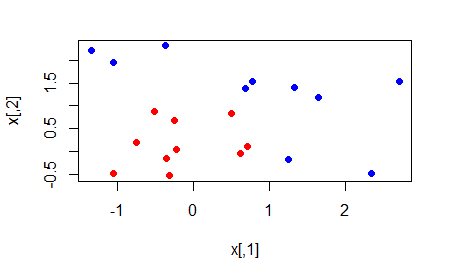

```r
#set a random seed
set.seed(10111)
#generated data, make a matrix x
x = matrix(rnorm(40), 20, 2)
#make y variable -1 or +1 with 10 in each class
y = rep(c(-1, 1), c(10, 10))
x[y == 1,] = x[y == 1,] + 1
#plot data
plot(x, col = y + 3, pch = 19)
```

Now loading package e1071 which contains SVM function

```r
library(e1071)
```

```r
dat = data.frame(x, y = as.factor(y))
svmfit = svm(y ~ ., data = dat, kernel = "linear", cost = 10,gamma=1)
print(svmfit)
```

```
Call:
svm(formula = y ~ ., data = dat, kernel = "linear",
    cost = 10, gamma = 1)


Parameters:
   SVM-Type:  C-classification
 SVM-Kernel:  linear
       cost:  10
      gamma:  1

Number of Support Vectors:  6
```

Printing the svmfit gives its summary. You can see that the number of support vectors is 6 - they are the points that are close to the boundary or on the wrong side of the boundary.

There’s a plot function for SVM that shows the decision boundary, as you can see below. It doesn’t seem there’s much control over the colors. It breaks with convention since it puts x2 on the horizontal axis and x1 on the vertical axis.

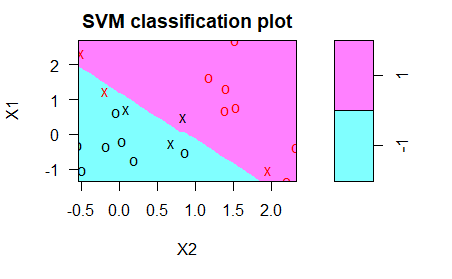

```r
plot(svmfit, dat)
```

```r
x
```

```
            [,1]        [,2]
 [1,]  0.4992207  0.83459057
 [2,] -0.5095988  0.86535664
 [3,] -0.3130123 -0.54000741
 [4,]  0.7136758  0.09454017
 [5,] -1.0506291 -0.49390571
 [6,] -0.7504743  0.19165412
 [7,] -0.3502830 -0.16827662
 [8,]  0.6202636 -0.03877393
 [9,] -0.2169360  0.03409674
[10,] -0.2485535  0.68234694
[11,]  1.3264276  1.40061717
[12,]  0.6886685  1.38550956
[13,]  2.7057305  1.52631182
[14,]  2.3354574 -0.49779748
[15,] -1.3406379  2.20544301
[16,]  1.2445945 -0.18418390
[17,]  0.7721881  1.53916368
[18,] -0.3640324  2.32334502
[19,]  1.6404738  1.17708567
[20,] -1.0440209  1.95016425
```

The first thing to do is to create a grid of values or a lattice of values for x1 and x2 that covers the whole domain on a fairly fine lattice. To do so, you make a function called make.grid. It takes in your data matrix x, as well as an argument n which is the number of points in each direction. Here you’re going to ask for a 75 x 75 grid.

Within this function, you use the apply function to get the range of each of the variables in x. Then for both x1 and x2, you use the seq function to go from the lowest value to the upper value to make a grid of length n. As of now, you have x1 and x2, each with length 75 uniformly-spaced values on each of the coordinates. Finally, you use the function expand.grid, which takes x1 and x2 and makes the lattice.

```r
#write a function
#create grid
make.grid = function(x, n = 75) {
  grange = apply(x, 2, range)
  x1 = seq(from = grange[1,1], to = grange[2,1], length = n)
  x2 = seq(from = grange[1,2], to = grange[2,2], length = n)
  expand.grid(X1 = x1, X2 = x2)
}
```

Now, I can apply make.grid function on x and check first 10 values from 1 to 10

```r
xgrid = make.grid(x)
xgrid[1:10,]
```

|  | X1 | X2 |
| --- | --- | --- |
| 1 | -1.3406379 | -0.5400074 |
| 2 | -1.2859572 | -0.5400074 |
| 3 | -1.2312766 | -0.5400074 |
| 4 | -1.1765959 | -0.5400074 |
| 5 | -1.1219153 | -0.5400074 |
| 6 | -1.0672346 | -0.5400074 |
| 7 | -1.0125540 | -0.5400074 |
| 8 | -0.9578733 | -0.5400074 |
| 9 | -0.9031927 | -0.5400074 |
| 10 | -0.8485120 | -0.5400074 |

As you can see, the grid goes through the 1st coordinate first, holding the 2nd coordinate fixed. Having made the lattice, you’re going to make a prediction at each point in the lattice. With the new data xgrid, you use predict and call the response ygrid. You then plot and color code the points according to the classification so that the decision boundary is clear. Let’s also put the original points on this plot using the points function.

svmfit has a component called index that tells which are the support points. You include them in the plot by using the points function again.

```r
ygrid = predict(svmfit, xgrid)
plot(xgrid, col = c("red","blue")[as.numeric(ygrid)], pch = 20, cex = .2)
points(x, col = y + 3, pch = 19)
```

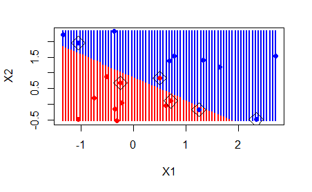

```r
points(x[svmfit$index,], pch = 5, cex = 2)
```

Here in boxes we can see 6 deciding points for SVM, which are close to decision boundary.

```r
beta = drop(t(svmfit$coefs)%*%x[svmfit$index,])
beta0 = svmfit$rho
plot(xgrid, col = c("red", "blue")[as.numeric(ygrid)], pch = 20, cex = .2)
points(x, col = y + 3, pch = 19)
```

```r
points(x[svmfit$index,], pch = 5, cex = 2)
abline(beta0 / beta[2], -beta[1] / beta[2])
```

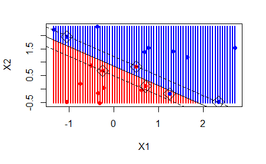

```r
abline((beta0 - 1) / beta[2], -beta[1] / beta[2], lty = 2)
abline((beta0 + 1) / beta[2], -beta[1] / beta[2], lty = 2)
```

**Non Linear SVM Classifier** You’re going to use the kernel support vector machine to try and learn that boundary. Load data

```r
load(file = "ESL.mixture.rda")
names(ESL.mixture)
```

```
[1] "x"        "y"        "xnew"     "prob"
[5] "marginal" "px1"      "px2"      "means"
```

```r
#remove old x and y from linear task
rm(x, y)
#atach new data
attach(ESL.mixture)
```

now, plot

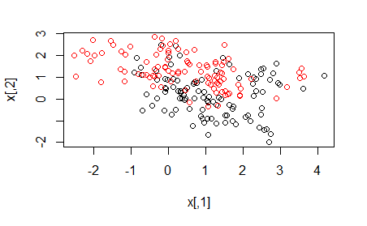

```r
plot(x, col=y+1)
```

There is a lot of overlapping data and no clear boundary/ Now, let’s make a data frame with the response y, and turn that into a factor. After that, you can fit an SVM with radial kernel and cost as 5.

```r
dat = data.frame(y = factor(y), x)
fit = svm(factor(y) ~ ., data = dat, scale = FALSE, kernel = "radial", cost = 5)
```

It’s time to create a grid and make your predictions. These data actually came supplied with grid points. If you look down on the summary on the names that were on the list, there are 2 variables px1 and px2, which are the grid of values for each of those variables. You can use expand.grid to create the grid of values. Then you predict the classification at each of the values on the grid.

```r
xgrid = expand.grid(X1 = px1, X2 = px2)
ygrid = predict(fit, xgrid)
```

Finally, you plot the points and color them according to the decision boundary. You can see that the decision boundary is non-linear. You can put the data points in the plot as well to see where they lie.

[figure not shown]

```r
plot(xgrid, col = as.numeric(ygrid), pch = 20, cex = .2)
points(x, col = y + 1, pch = 19)
```

First, you predict your fit on the grid. You tell it decision values equal TRUE because you want to get the actual function, not just the classification. It returns an attribute of the actual classified values, so you have to pull of that attribute. Then you access the one called decision.

Next, you can follow the same steps as above to create the grid, make the predictions, and plot the points.

```r
func = predict(fit, xgrid, decision.values = TRUE)
func = attributes(func)$decision
xgrid = expand.grid(X1 = px1, X2 = px2)
ygrid = predict(fit, xgrid)
plot(xgrid, col = as.numeric(ygrid), pch = 20, cex = .2)
points(x, col = y + 1, pch = 19)
```

```r
contour(px1, px2, matrix(func, 69, 99), level = 0, add = TRUE)
```

```
data length [5625] is not a sub-multiple or multiple of the number of rows [69]
```

```
data length [5625] is not a sub-multiple or multiple of the number of rows [69]
```

[figure not shown]

```r
contour(px1, px2, matrix(func, 69, 99), level = 0.5, add = TRUE, col = "blue", lwd = 2)
```

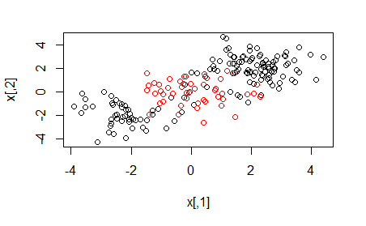

```r
set.seed (1)
x=matrix (rnorm (200*2) , ncol =2)
x[1:100 ,]=x[1:100 ,]+2
x[101:150 ,]= x[101:150 ,] -2
y=c(rep (1 ,150) ,rep (2 ,50) )
dat=data.frame(x=x,y=as.factor (y))
plot(x, col=y)
```

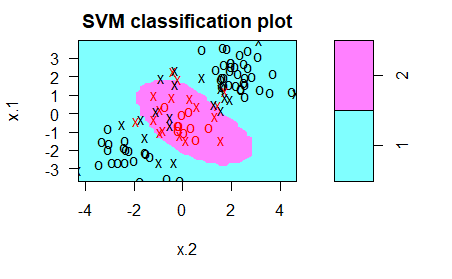

```r
train=sample (200 ,100)
svmfit =svm(y∼., data=dat[train ,], kernel ="radial", gamma =1, cost =1)
plot(svmfit , dat[train ,])
```

```r
summary(svmfit )
```

```
Call:
svm(formula = y ~ ., data = dat[train, ], kernel = "radial",
    gamma = 1, cost = 1)


Parameters:
   SVM-Type:  C-classification
 SVM-Kernel:  radial
       cost:  1
      gamma:  1

Number of Support Vectors:  37

 ( 17 20 )


Number of Classes:  2

Levels:
 1 2
```

The plot shows that the resulting SVM has a decidedly non-linear boundary. The summary() function can be used to obtain some information about the SVM fit:

We can see from the figure that there are a fair number of training errors in this SVM fit. If we increase the value of cost, we can reduce the number of training errors. However, this comes at the price of a more irregular decision boundary that seems to be at risk of overfitting the data.

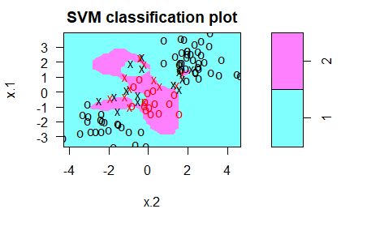

```r
svmfit =svm(y∼., data=dat [train ,], kernel ="radial",gamma =1, cost=1e5)
plot(svmfit ,dat [train ,])
```

We can perform cross-validation using tune() to select the best choice of γ and cost for an SVM with a radial kernel:

```r
set.seed (1)
tune.out=tune(svm , y∼., data=dat[train ,], kernel ="radial",
ranges =list(cost=c(0.1 ,1 ,10 ,100 ,1000), gamma=c(0.5,1,2,3,4) ))
summary (tune.out)
```

```
Parameter tuning of ‘svm’:

- sampling method: 10-fold cross validation

- best parameters:
```

|  | cost | gamma |
| --- | --- | --- |
|  | 1 | 2 |

```
- best performance: 0.12

- Detailed performance results:
```

| cost | gamma | error | dispersion |
| --- | --- | --- | --- |
| 1e-01 | 0.5 | 0.27 | 0.11595018 |
| 1e+00 | 0.5 | 0.13 | 0.08232726 |
| 1e+01 | 0.5 | 0.15 | 0.07071068 |
| 1e+02 | 0.5 | 0.17 | 0.08232726 |
| 1e+03 | 0.5 | 0.21 | 0.09944289 |
| 1e-01 | 1.0 | 0.25 | 0.13540064 |
| 1e+00 | 1.0 | 0.13 | 0.08232726 |
| 1e+01 | 1.0 | 0.16 | 0.06992059 |
| 1e+02 | 1.0 | 0.20 | 0.09428090 |
| 1e+03 | 1.0 | 0.20 | 0.08164966 |

[output cut: 15 more lines]

```
NA
```

Therefore, the best choice of parameters involves cost=1 and gamma=2. We can view the test set predictions for this model by applying the predict() function to the data. Notice that to do this we subset the dataframe dat using -train as an index set.

```r
table(true=dat[-train ,"y"], pred=predict (tune.out$best.model , newdata =dat[-train ,]))
```

```
    pred
true  1  2
   1 74  3
   2  7 16
```

10% of test observations are misclassified by this SVM.